# Introduction to statistics for hypothesis testing

## ANOVA and F-tests

We now turn to experiments with more than two conditions, which are often analysed with "Analysis of Variance" (ANOVA) (thanks again to Fisher). In such cases, we may be interested in any differences between three or more conditions; a hypothesis that cannot be tested with a T-statistic, but can be tested with the F-statistic.

Calculation of the F-statistic within the GLM is a bit complex (see "glm_con"), but can be throught as comparing the variance explained by two models: the full model (with the effects of interest) relative to a reduced model (without effects of interest), where the effects of interest are specified by an F-contrast. Whereas the contrast vector c for a T-contrast is always one-dimensional (one row), an F-contrast can have more than one row (i.e., becomes a contrast matrix). This is easiest to explain with the concept of a 1x3 repeated-measures ("within-participant") ANOVA:

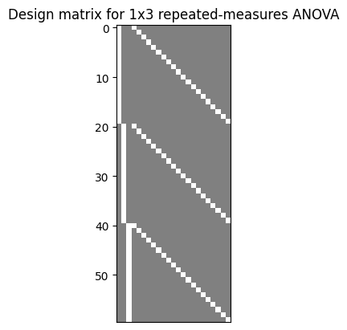

```python
nc = 3 # Number of conditions
X = np.append(np.kron(np.eye(nc),np.ones((N,1))), np.kron(np.ones((nc,1)),np.eye(N)), axis=1)
plt.figure(); plt.imshow(X, cmap='gray', vmin=-1, vmax=1);
plt.title('Design matrix for 1x3 repeated-measures ANOVA'); plt.xticks([]);
```

We are now also going to generate data using a multivariate normal distribution (as if we had sampled the same person in a population several times), in which we can specify the correlation between measures from the same people (the variable "ppt_cor" below, the size of which determines how much more efficient within-participant designs can be; a parameter also often needed for power analyses):

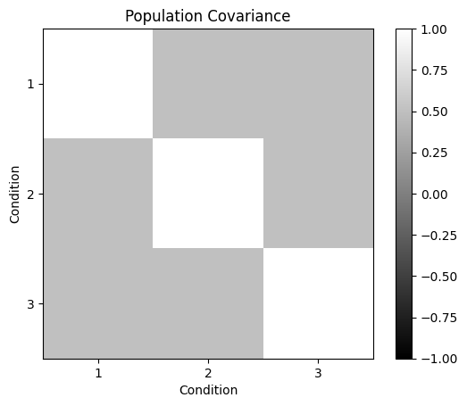

```python
np.random.seed(1) # Initialise random seed
pop_means = np.array([1, 2, 3])/nc # Means across 3 conditions
ppt_cor = 0.5 # correlation between measures from same participants
pop_cov = np.ones((nc,nc))*ppt_cor + (1-ppt_cor)*np.eye(nc) # covariance matrix
plt.figure(); plt.imshow(pop_cov, cmap='gray', vmin=-1, vmax=1);
plt.title('Population Covariance'); plt.xticks([0,1,2],labels=[1,2,3]); plt.yticks([0,1,2],[1,2,3])
plt.xlabel('Condition'); plt.ylabel('Condition'); plt.colorbar();
y = np.random.multivariate_normal(pop_means, pop_cov, N) # Generate correlated data
y = np.concatenate(y.T,axis=0) # Concatenate (from "wide" to "long" format)
```

If we want to test whether the means of the three conditions differ in any way, we can specify an F-contrast with any of the contrast matrices below (which are all equivalent, and have same rank):

```python
print('Equivalent F-contrasts:')
print('Does condition 1 differ from 2, and/or condition 2 from 3?')
c = np.array([[1, -1, 0], [0, 1, -1]]); print(c)
print('Does any condition differ from average of other two?')
c = np.array(sp.signal.detrend(np.eye(3),axis=0,type='constant')); print(c)
print('Orthonormal contrast (generally safest)')
c,_ = np.linalg.qr(np.diff(np.eye(3), axis=0).T); c = c.T; print(c)
```

```
Equivalent F-contrasts:
Does condition 1 differ from 2, and/or condition 2 from 3?
[[ 1 -1  0]
 [ 0  1 -1]]
Does any condition differ from average of other two?
[[ 0.66666667 -0.33333333 -0.33333333]
 [-0.33333333  0.66666667 -0.33333333]
 [-0.33333333 -0.33333333  0.66666667]]
Orthonormal contrast (generally safest)
[[-0.70710678  0.70710678  0.        ]
 [-0.40824829 -0.40824829  0.81649658]]
```

We'll just create a little function to create orthonormal contrasts for generic ANOVAs later:

```python
def ortho_con(N):
    c,_ = np.linalg.qr(np.diff(np.eye(N), axis=0).T)
    return(c.T)
```

Note also that, whereas T-tests (within GLM) are always directional, F-contrasts are always non-directional, and the sign of the contrast weights does not matter. Indeed, for 1D case, F=T^2, equivalent to a two-tailed T-test. As with a T-contrast, the scaling of the weights within each row does not matter, though that scaling does need to be the same across rows. One way to think about an F-contrast is as the union of effects in each row, e.g, for the first contrast above, asking whether conditions 1 and 2 differ AND/OR whether conditions 2 and 3 differ. Or in geometric terms, for a 2D design matrix, you can think of a T-test as testing the distance along the projection of the data onto one direction through that 2D space, whereas the F-test is testing the distance from the origin, i.e, a circular exclusion zone.

The distribution of the F-statistic is determined by two dfs: the numerator df refers to the (dimensionality/rank of) the effects of interest, as specified by the F-contrast (with value 2 for examples above), whereas the denominator df refers to the remaining dfs in the data. A p-value can then be calculated from the parametric distribution of the F-statistic:

```python
T,F,df,p,B,R2,r = glm(y, X, c)
print(f'Main effect in 1x3 ANOVA: F({int(df[0])},{int(df[1])})={F.item():.3f}, p={p.item():.3f}')
```

```
Main effect in 1x3 ANOVA: F(2,38)=3.397, p=0.044
```

**Exercise: how can one test for a linear effect across three conditions? You might think a contrast [-1 0 1] on above design matrix will do this, but this only compares the two extreme levels, i.e, could return a significant positive effect even if the means of the data were [1 -3 2]. The solution is to fit a more restricted model in which the first three columns of X are replaced with a single column capturing only a linear effect, ie by setting X = np.append(X[:,:3] @ np.array([[-1],[0],[1]]), X[:,3:]) and testing a contrast c = [1] (np.ones((1,1))).**

### Nonsphericity (inhomogeniety of error (co)variance)

However there are situations in which the above p-values can be incorrect (ie FPR too high). Above we stated that the GLM assumes the error is drawn independently from a single Gaussian. This assumption is sometimes described as the residuals being "white", or "independent and identically distributed" (IID). In fact, the more precise assumption for these ANOVA designs is that the error covariance across conditions is "spherical". Sphericity is complicated to define, but a common case that meets sphericity is that the covariance matrix has "compound symmetry", which means that all the diagonal values are equal (homogeniety of variance, or heteroscedasticity) and all the off-diagonal values are equal (homogeniety of covariance). The pop_cov matrix above is compound symmetric, and the simulations below confirm that the FPR is controlled. But notice what happens between when either homogeniety of variance (as we met above in case of unpaired T-tests) or homogeniety of covariance are not met:

```python
np.random.seed(2) # Initialise random seed
num_samp = int(1e3)
p = np.empty((num_samp,3))
for s in range(num_samp):
    # 1. compound symmetry
    pop_cov = [[1, 0.5, 0.5], [0.5, 1, 0.5], [0.5, 0.5, 1]]
    y = np.random.multivariate_normal(np.zeros(3), pop_cov, N)
    y = np.concatenate(y.T,axis=0)
    T,F,df,pval,B,R2,r = glm(y, X, c)
    p[s,0] = pval.item()

    # 2. inhomogeniety of covariance
    pop_cov = [[1, 0.8, 0.4], [0.8, 1, 0.8], [0.4, 0.8, 1]]
    y = np.random.multivariate_normal(np.zeros(3), pop_cov, N)
    y = np.concatenate(y.T,axis=0)
    T,F,df,pval,B,R2,r = glm(y, X, c)
    p[s,1] = pval.item()

    # 3. inhomogeniety of variance
    pop_cov = [[0.1, 0, 0], [0, 1, 0], [0, 0, 10]]
    y = np.random.multivariate_normal(np.zeros(3), pop_cov, N)
    y = np.concatenate(y.T,axis=0)
    T,F,df,pval,B,R2,r = glm(y, X, c)
    p[s,2] = pval.item()

fpr = np.sum(p < alpha, axis=0) / num_samp
print(f'Compound symmetric covariance, FPR={fpr[0]:.3f}')
print(f'Inhomogeniety of covariance,   FPR={fpr[1]:.3f}')
print(f'Inhomogeniety of variance,     FPR={fpr[2]:.3f}')
```

```
Compound symmetric covariance, FPR=0.047
Inhomogeniety of covariance,   FPR=0.079
Inhomogeniety of variance,     FPR=0.084
```

Only the first example controls FPR at alpha, while FPR is elevated for the other two cases (the second example of inhomogeniety of covariance resembles the autocorrelation when y is a timeseries, as discussed later). A common way to correct for this nonsphericity is to adjust (reduce) the dfs, as we saw earlier in Welch's correction for inhomogeneous variances. The general approach uses what is called the Satterthwaite approximation (but variants include Greenhouse-Geisser or Huyn-Feldt). You can test this by passing a fourth argument to "glm", which tells it how many conditions of interest there are. This estimates the covariance across conditions from the residuals, and reduces the dfs accordingly.

**Exercise: add the number of conditions as an additional argument to glm above, eg "glm(y, X, c, 3)", and you should see the FPR is now better controlled in all cases.**

### Factorial designs

Often experimental conditions are generated by a factorial design, where each condition corresponds to one level of each of multiple factors. For example, a design with two factors each with two levels would have 4 conditions, and corresponds to "2x2 ANOVA". Factorial designs are associated with a common set of contrasts (hypotheses): main effects of each factor plus interactions between them. For example, if we have factor F1 with levels A and B, and factor F2 with levels 1 and 2, and we order the four conditions in X as [A1 A2 B1 B2], then:

```python
c1 = np.kron([-1, 1], [1,  1])
print(f'Main effect of F1: \t\t{c1}')
c2 = np.kron([1,  1], [-1, 1])
print(f'Main effect of F2: \t\t{c2}')
c3 = np.kron([-1, 1], [-1, 1])
print(f'Interaction between F1 and F2: \t{c3} (difference of differences)')
```

```
Main effect of F1: 		[-1 -1  1  1]
Main effect of F2: 		[-1  1 -1  1]
Interaction between F1 and F2: 	[ 1 -1 -1  1] (difference of differences)
```

More generally, all possible main effects and interactions in a factorial design can be generated by the Kronecker product of two contrasts for each factor f with P[f] levels: 1) "np.ones(P[f])" for the common effect across levels, and 2) the orthonormal contrast for the difference between levels, as defined in the F-contrasts section above, eg:

```python
P = [2, 3] # 2 x 3 ANOVA
m = []; d = []
for f in range(len(P)):
    m.append(np.ones(P[f]))
    d.append(ortho_con(P[f]))
print('Example of main effect of second factor in 2x3 design:')
c = np.kron(m[0],d[1]); print(c)
print('Example of interaction between two factors in 2x3 design:')
c = np.kron(d[0],d[1]); print(c)
```

```
Example of main effect of second factor in 2x3 design:
[[-0.70710678  0.70710678  0.         -0.70710678  0.70710678  0.        ]
 [-0.40824829 -0.40824829  0.81649658 -0.40824829 -0.40824829  0.81649658]]
Example of interaction between two factors in 2x3 design:
[[ 0.5        -0.5        -0.         -0.5         0.5         0.        ]
 [ 0.28867513  0.28867513 -0.57735027 -0.28867513 -0.28867513  0.57735027]]
```

*Interesting factoid: Leonold Kronecker's famous saying was "Die ganzen Zahlen hat der liebe Gott gemacht, alles andere ist Menschenwerk" ("God made the integers, all else is the work of man")*

### Pooled vs partitioned error

When all conditions are between-participant (i.e., each condition is a group), we can have a single X with as many columns as there are groups, within which we can evaluate every ANOVA F-contrast like above. We do not have to worry about inhomogeniety of covariance (because true covariances are 0 when participants are assumed to be independent), though we should worry about inhomogeniety of variance (using the Satterthwaite approximation mentioned above).

When one or more factors are within-participant, however, we have possible inhomogeniety of covariance too. One way to reduce this nonsphericity problem is to "partition" the error into separate error terms for each ANOVA effect (rather than the "pooled" error used so far). Because the columns in X for ANOVA designs are orthogonal (as are the rows of orthonormal F-contrasts for each ANOVA effect), we can effectively fit a separate (reduced) design matrix for each ANOVA effect by pre-muliplying the data by these F-contrasts. This is illustrated before for a 2x2 design in which both factors are within-participant:

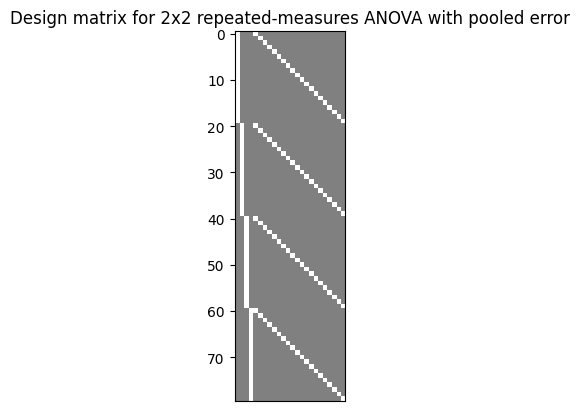

```python
np.random.seed(1) # Initialise random seed
nc = 4; N = 20
X = np.append(np.kron(np.eye(nc),np.ones((N,1))), np.kron(np.ones((nc,1)),np.eye(N)), axis=1)
plt.figure(); plt.imshow(X, cmap='gray', vmin=-1, vmax=1);
plt.title('Design matrix for 2x2 repeated-measures ANOVA with pooled error'); plt.xticks([]);
```

```python
es = np.array([3, 2, 1])/3 # Effect sizes for main effects and interaction (not standardised effect sizes though!)
pop_means = es @ np.array([c1, c2, c3])/4 # Project to conditions using ANOVA contrasts above
#pop_cov = np.ones((4,4))*ppt_cor + (1-ppt_cor)*np.eye(4) # covariance matrix
pop_cov = [[1, 0.8, 0, 0], [0.8, 1, 0, 0], [0, 0, 0.5, 0.3], [0, 0, 0.3, 0.5]] # nonspherical case
y = np.random.multivariate_normal(pop_means, pop_cov, N) # Generate correlated data
y = np.concatenate(y.T,axis=0)

# Pooled error (using c1-c3 effect contrasts from above)
B, sigma, R2, r = glm_fit(y, X)
T, F, df, p = glm_con(c1, X, B, sigma, r, nc)
print(f'Contrast {c1}, F({df[0].item():.3f}, {df[1].item():.3f}) = {F.item():.3f}, pooled p={p.item():.3f}')
T, F, df, p = glm_con(c2, X, B, sigma, r, nc)
print(f'Contrast {c2}, F({df[0].item():.3f}, {df[1].item():.3f}) = {F.item():.3f}, pooled p={p.item():.3f}')
T, F, df, p = glm_con(c3, X, B, sigma, r, nc)
print(f'Contrast {c3}, F({df[0].item():.3f}, {df[1].item():.3f}) = {F.item():.3f}, pooled p={p.item():.3f}')
print('\n')

# Partitioned error (using c1-c3 effect contrasts from above)
c = np.kron(c1,np.eye(N))
Xc = np.ones((N,1)) # Here one-sample T-test; more generally Xc = c@X
B, sigma, R2, r = glm_fit(c@y, Xc)
T, F, df, p = glm_con(np.array([1]), Xc, B, sigma, r)
print(f'Contrast {c1}, F{int(df[0]), int(df[1])} = {F.item():.3f}, partitioned p={p.item():.3f}')
c = np.kron(c2,np.eye(N))
B, sigma, R2, r = glm_fit(c@y, Xc)
T, F, df, p = glm_con(np.array([1]), Xc, B, sigma, r)
print(f'Contrast {c2}, F{int(df[0]), int(df[1])} = {F.item():.3f}, partitioned p={p.item():.3f}')
c = np.kron(c3,np.eye(N))
B, sigma, R2, r = glm_fit(c@y, Xc)
T, F, df, p = glm_con(np.array([1]), Xc, B, sigma, r)
print(f'Contrast {c3}, F{int(df[0]), int(df[1])} = {F.item():.3f}, partitioned p={p.item():.3f}')
```

```
Contrast [-1 -1  1  1], F(0.533, 30.363) = 13.658, pooled p=0.000
Contrast [-1  1 -1  1], F(0.533, 30.363) = 5.446, pooled p=0.013
Contrast [ 1 -1 -1  1], F(0.533, 30.363) = 2.040, pooled p=0.082


Contrast [-1 -1  1  1], F(1, 19) = 5.809, partitioned p=0.013
Contrast [-1  1 -1  1], F(1, 19) = 18.551, partitioned p=0.000
Contrast [ 1 -1 -1  1], F(1, 19) = 5.743, partitioned p=0.014
```

The p-values from the pooled error are sometimes smaller, due to larger dfs, but those from the partitioned approach are safer because the error covariance matrix is smaller (since fewer conditions per model), so sphericity assumptions more likely to be met (indeed, when there are only 2 levels per factor, as here, the GLM only has one column and hence one covariance term, so the error must be spherical by definition).

**Exercise: if you want to check robustness of partitioned error to nonspheriricty, run above code over num_samp studies to calculate FPR**

Note permutation testing is possible with these more complex ANOVA models, but can be tricky because the exchangeability requirement restricts how exactly participants can be swapped between conditions. Indeed, for the case of timeseries considered below, where every datapoint can be dependent on others, randomisation is very tricky (though one can phase-shuffle data while maintaining the power spectrum, i.e, autocorrelation). By contrast, the strength of the parametric assumptions of the GLM comes with the flexibility they afford, as exemplified below.

### Continuous regressors (multiple regression)

So far we have applied the GLM to experiments with one or more conditions, in which the values in X are binary, but it can equally be applied to continuous values in X, e.g, to perfom multiple regression. The simplest example of this is to estimate the correlation between two variables:

```
Pearson correlation, R(20)=0.32, p=0.164
GLM F-test, F(1, 18) = 2.101, p=0.164 (R2=0.71)
```

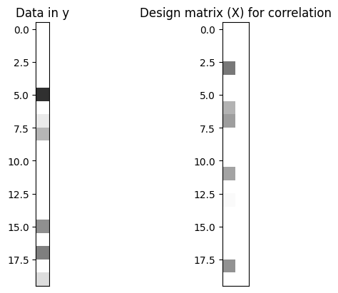

```python
np.random.seed(2) # Initialise random seed
pop_cov = np.ones(2)*ppt_cor + (1-ppt_cor)*np.eye(2) # covariance matrix
y = np.random.multivariate_normal(np.ones(2), pop_cov, N) # Mean of 1

Rp = sp.stats.pearsonr(y[:,0], y[:,1]) # Pearson correlation
print(f'Pearson correlation, R({N})={Rp[0]:.2f}, p={Rp[1]:.3f}')

X = np.append(y[:,1][:,np.newaxis], np.ones((N,1)),axis=1)
T,F,df,p,B,R2,r = glm(y[:,0], X, np.array([1,0]))
p = p*2 # GLM T-test one-tailed by default, so double for two-tailed
print(f'GLM F-test, F{int(df[0]), int(df[1])} = {F.item():.3f}, p={p.item():.3f} (R2={R2[0].item():.2f})')

plt.figure(); plt.subplot(1, 2, 1)
plt.imshow(y[:,0][:,np.newaxis], cmap='gray', vmin=-1, vmax=1)
plt.title('Data in y'); plt.xticks([]);
plt.subplot(1, 2, 2); plt.imshow(X, cmap = 'gray', vmin=-1, vmax=1)
plt.title('Design matrix (X) for correlation'); plt.xticks([]);
```

The F-contrast on first column of X gives same p-value as standard Pearson correlation. Note that it is important to include the second, constant term in X, to remove the mean (if you do not include it, and the means of y(:,1) and y(:,2) are not zero, then the p-value will not correspond to a correlation, but include the effect of the means). You will also note that the sqrt(R2) does not equal the Pearson correlation coefficient Rp. This is because R2 above refers to whole model fit, including mean. To estimate the Pearson correlation coefficient, you could mean-correct y:

```python
#my = y - np.repeat(np.mean(y, axis=0), y.shape[0], axis=0)  # mean-correct y
my = sp.signal.detrend(y,axis=0,type='constant')
T,F,df,p,_,R2,r = glm(my[:,[0]], my[:,[1]], np.array([1]))
p = p*2 # If contrast vector 1d, GLM assumes (one-tailed) T-test, so double to get (two-tailed) p-value for F-test
R2 = R2[0].item()
R = np.sqrt(R2)
print(f'GLM: R2={R2:.2f}, R={R:.2f}, F{int(df[0]), int(df[1])}={F.item():.3f}, p={p.item():.3f}')
```

```
GLM: R2=0.10, R=0.32, F(1, 19)=2.218, p=0.153
```

(though there are other ways of calculating R2 from sub-spaces of X specified by the contrast). While we have now recovered the Pearson coefficient, note that the p-value is no longer quite correct, because we removed df's from the data when we mean-corrected, but not told the model about this. This is why it is generally best not to perform any operations on the data (like mean-correction) before entering them into the GLM; rather you should include such operations in the GLM if possible (e.g, adding a constant term, or filter the model if also filtering the timeseries, see later).

*Interesting factoid: Karl Pearson made many contributions to statistics, though like his colleague Fisher, he was tarred by his views on eugenics. However, correlation is not causation, and statistical training does not necessarily result in eugenic beliefs.*

We can plot the fit and data from the original example above:

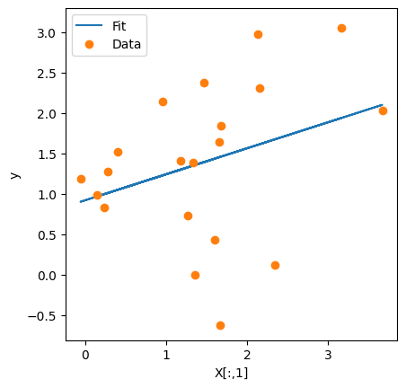

```
Parameter estimates from original GLM above: B1=0.32, B2=0.92
```

```python
Y = X @ B  # Reconstruct fitted response
plt.figure()
plt.plot(X[:, 0], Y, '-', label='Fit')
plt.plot(y[:, 1], y[:, 0], 'o', label='Data')
plt.legend(); plt.axis('square')
ax = plt.gca()
#ax.spines['left'].set_position('zero'); ax.spines['left'].set_color('none')
#ax.spines['bottom'].set_position('zero'); ax.spines['bottom'].set_color('none')
plt.ylabel('y'); plt.xlabel('X[:,1]')
plt.show()
print(f'Parameter estimates from original GLM above: B1={B[0]:.2f}, B2={B[1]:.2f}')
```

You can see that B1 corresponds to the slope of the fit (regression line), whereas B2 is the intercept (value expected when variable in X(:,1) is zero). What happens if we mean-correct X(:,1):

```python
mX = X.copy()
mX[:, 0] = X[:, 0] - np.mean(X[:, 0])
T,F,df,p,mB,R2,r = glm(y[:,0], mX, np.array([1, 0]))
p = p*2 # If contrast vector 1d, GLM assumes (one-tailed) T-test, so double to get (two-tailed) p-value for F-test
print(f'GLM F-test, F({int(df[0])},{int(df[1])})={F.item():.2f}, p={p.item():.3f}')
print(f'Parameter estimates after mean-correction: B1={mB[0]:.2f}, B2={mB[1]:.2f}')
print(f'Mean of data={np.mean(y[:, 0]):.2f}')
```

```
GLM F-test, F(1,18)=2.10, p=0.164
Parameter estimates after mean-correction: B1=0.32, B2=1.38
Mean of data=1.38
```

You can see that B1 (the slope) has not changed (and nor have the statistics), but B2 has, and it now reflects the mean of the data, not the intercept. This is a special case of orthogonalising regressors, to which we now turn.

### Correlated Regressors and Orthogonalisation

Let's now fit the data will two continuous regressors, but make them highly correlated:

```python
np.random.seed(2) # Initialise random seed
pop_cov = [[1, 0.5, 0.5], [0.5, 1, 0.9], [0.5, 0.9, 1]] # covariance matrix
N = 30
y = np.random.multivariate_normal(np.ones(3), pop_cov, N) # Mean of 1
```

If we fit each regressor separately, the p-value is usually small:

```python
T,F,df,p,B,R2,r = glm(y[:,[0]], np.append(y[:,[1]], np.ones((N,1)), axis=1), np.array([1]))
print(f'Separate GLM T-test for 1st regressor T({int(df[1])}) = {T.item():.3f}, p={p.item():.3f}')
T,F,df,p,B,R2,r = glm(y[:,[0]], np.append(y[:,[2]], np.ones((N,1)), axis=1), np.array([1]))
print(f'Separate GLM T-test for 2nd regressor T({int(df[1])}) = {T.item():.3f}, p={p.item():.3f}')
```

```
Separate GLM T-test for 1st regressor T(28) = 3.006, p=0.003
Separate GLM T-test for 2nd regressor T(28) = 2.731, p=0.005
```

However, when we add both to the same model:

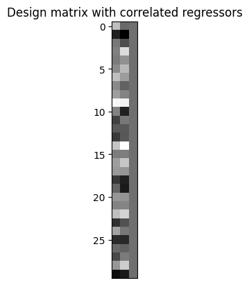

```python
X = np.append(y[:,1:3], np.ones((N,1)), axis=1)
plt.figure(); plt.imshow(X, cmap='gray');
plt.title('Design matrix with correlated regressors'); plt.xticks([]);
```

```python
T,F,df,p,B,R2,r = glm(y[:,[0]], X, np.array([1, 0, 0]))
print(f'Joint GLM T-test for 1st regressor T({int(df[1])}) = {T.item():.3f}, p={p.item():.3f}')
T,F,df,p,B,R2,r = glm(y[:,[0]], X, np.array([0, 1, 0]))
print(f'Joint GLM T-test for 2nd regressor T({int(df[1])}) = {T.item():.3f}, p={p.item():.3f}')
```

```
Joint GLM T-test for 1st regressor T(27) = 1.365, p=0.092
Joint GLM T-test for 2nd regressor T(27) = 0.798, p=0.216
```

...rarely is either individual regressor significant. This is because the parameter estimates from a GLM only reflect the unique variance explained by each regressor. Note however that an F-test across both regressors produces a significant result because it includes the shared variance:

```python
T, F, df, p = glm_con(np.array([[1, 0, 0], [0, 1, 0]]).T, X, B, sigma, r)
print(f'Joint GLM F-test for 1st and 2nd regressor, F{int(df[0]), int(df[1])}={F.item():.3}, p={p.item():.3}')
```

```
Joint GLM F-test for 1st and 2nd regressor, F(2, 27)=4.78, p=0.0167
```

Sometimes people orthogonalise one regressor with respect to the other. This can be done with the "orthog" function below (which actually just residualises one regressor by fitting a GLM that predicts it by the other). So let's orthogonalise the first regressor with respect to the second:

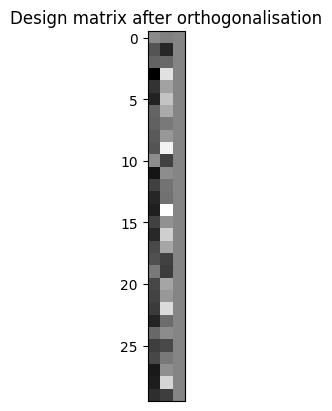

```python
orthog = lambda x,y: x - y @ np.linalg.pinv(y) @ x # orthogonalise x with respect to y

oX = X.copy()
oX[:,[0]] = orthog(X[:,[0]], X[:,[1]]) # orthogonalise 1st regressor with respect to 2nd
plt.figure(); plt.imshow(oX, cmap='gray');
plt.title('Design matrix after orthogonalisation'); plt.xticks([]);
```

```python
print(f'Previous Betas: \t\t{np.ndarray.flatten(B)}')
T,F,df,p,B,R2,r = glm(y[:,[0]], oX, np.array([1, 0, 0]))
print(f'Betas after orthogonalisation: \t{np.ndarray.flatten(B)}')
print(f'Orthog GLM T-test for 1st regressor T({int(df[1])}) = {T.item():.3f}, p={p.item():.3f}')
T,F,df,p,B,R2,r = glm(y[:,[0]], oX, np.array([0, 1, 0]))
print(f'Orthog GLM T-test for 2nd regressor T({int(df[1])}) = {T.item():.3f}, p={p.item():.3f}')
```

```
Previous Betas: 		[ 0.63908908  0.30726968 -0.26499199]
Betas after orthogonalisation: 	[ 0.63908908  0.87230875 -0.26499199]
Orthog GLM T-test for 1st regressor T(27) = 1.365, p=0.092
Orthog GLM T-test for 2nd regressor T(27) = 3.091, p=0.002
```

As with mean-correction in the previous examine of correlations, the Beta and p-value for the regressor that has been orthogonalised (B1) does not change, but those for the other regressor do, because now the common variance between the two has been assigned to it. However, there is no magic here - in general, one cannot know how to assign common variance to two or more correlated variables - there should always be an independent reason for giving priority to one over another. (Sometimes, in unbalanced ANOVA designs in which the columns of X are no longer orthogonal, priority is given to lower-order effects, e.g. main effects over interactions. This corresponds to differences between "Type I, II and III sum of squares"; which are effectively just different orders of orthogonalisation.)

Finally, note that sometimes the GLM regressors are Z-scored; again, this does not affect tests of the significance of individal parameter estimates (when there is a constant term in X), but the scaling by their std does affect their Betas, and hence any contrasts between those Betas (and this is often important, in order to put the parameters onto the same scale, ie make them commensurate, if they do not already have meaningful units of comparison).

### Efficiency

Importantly, high correlation between regressors in a GLM reduces the power with which their unique contributions (parmeters) can be estimated. It does not bias the parameter estimates or statistical tests on them (e.g., when data is generated from a weighted combination of both of them); it just makes those estimates (weights) highly variable across experiments (i.e. different data samples). Indeed, the correlation between regressors is inherent to the definition of the efficiency of a GLM to test a specific hypothesis, which is a function of the design matrix and contrast:

```python
efficiency = lambda X,c: np.trace(c @ np.linalg.inv(X.T @ X) @ c.T)**-1 # scaling arbitrary
```

High correlation between columns of X reduces the middle term in this equation. Note however that the contrast itself also matters, so it may not matter if regressors are (negatively) correlated, if one only cares about the difference between them, as in the example below, where efficiency for the difference between the slopes of two regressors is much higher than that for their average slope:

```python
np.random.seed(1) # Initialise random seed
pop_cov = [[1, -0.5], [-0.5, 1]] # covariance matrix
X = np.random.multivariate_normal(np.ones(2), pop_cov, N)
X = np.append(X, np.ones((N,1)), axis=1)
c = np.array([[1, 1, 0]])
print(f'Efficiency of Contrast {np.ndarray.flatten(c)} = {efficiency(X,c):.3f}')
c = np.array([[1, -1, 0]])
print(f'Efficiency of Contrast {np.ndarray.flatten(c)} = {efficiency(X,c):.3f}')
```

```
Efficiency of Contrast [1 1 0] = 6.883
Efficiency of Contrast [ 1 -1  0] = 14.681
```

Or in the extreme case, the columns of a two-sample T-test are perfectly anti-correlated, which means one cannot estimate one condition independently of the other (when a constant term is included), and efficiency above is not defined, but one can still estimate the difference between the two conditions.

**Exercise (advanced): this definition of efficiency is helpful when comparing different fMRI designs, where the effects of correlations between regressors induced by the HRF and by the onsets of different conditions is difficult to intuit. You could try estimating efficiency for variants of the fMRI GLM below (taking care to match the scaling of X and c). More generally, this webpage explains how to design efficient fMRI experiments: https://imaging.mrc-cbu.cam.ac.uk/imaging/DesignEfficiency**

### Nonlinear effects

Finally, we are assuming a linear relationship between y and (each regressor in) X. In general the relationship could be nonlinear, and while there are several ways of modelling this, the simplest approach is through a polynomial expansion, as defined here:

```python
def polynom(x, n, z=1, o=1):
    # Return polynomial expansion of data matrix x to order n
    # (each order orthogonalised wrt lower orders, and normalised by std)

    if n > N:
        raise ValueError(f"{n}th order expansion not possible for only {N} points")

    X = np.ones((N, 1))  # 0th order (intercept)

    for p in range(1, n+1):
        for q in range(x.shape[1]):
            d = x[:, q]
            nX = d ** p
            if o == 1:
                nX = orthog(nX, X)
            if p > 0 and z == 1:
                nX = nX / np.std(nX)
            X = np.append(X, nX[:,np.newaxis], axis=1)
    return X
```

(Here there is a good reason to orthogonalise higher order terms with respect to lower order ones, ie to assign any shared variance to lower order terms). This example detects a pure quadratic relationship between y and the original variable x:

```
0th-order (intercept) effect, T(27)=0.97, p=0.17
1st-order (linear) effect, T(27)=-2.22, p=0.983
2nd-order (quadratic) effect, T(27)=7.09, p=6.4e-08
F-test for overall effect, F(3, 27)=18.7, p=9.12e-07
```

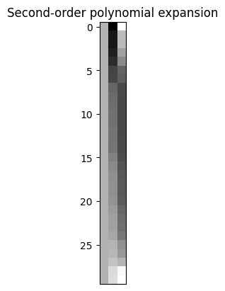

```python
x = np.sort(X[:,[0]], axis=0) # Sort first regressor from above to aid visualisation
# Create pure quadratic effect plus noise
y = sp.signal.detrend(x,axis=0,type='constant')**2 # remove mean first
y = sp.signal.detrend(y,axis=0,type='constant') # remove mean after
y = y + np.random.randn(N,1)

X = polynom(x,2)
plt.figure(); plt.imshow(X, cmap='gray');
plt.title('Second-order polynomial expansion'); plt.xticks([]);

T,F,df,p,B,R2,r = glm(y, X, np.array([1, 0, 0]))
print(f'0th-order (intercept) effect, T({int(df[1])})={T.item():.3}, p={p.item():.3}')
T,F,df,p,B,R2,r = glm(y, X, np.array([0, 1, 0]))
print(f'1st-order (linear) effect, T({int(df[1])})={T.item():.3}, p={p.item():.3}')
T,F,df,p,B,R2,r = glm(y, X, np.array([0, 0, 1]))
print(f'2nd-order (quadratic) effect, T({int(df[1])})={T.item():.3}, p={p.item():.3}')
T,F,df,p,B,R2,r = glm(y, X, np.eye(3))
print(f'F-test for overall effect, F{int(df[0]), int(df[1])}={F.item():.3}, p={p.item():.3}')
```

The first three T-tests test for constant, linear and quadratic effects respectively, while more common is the final F-test, which captures *any* dependency between y and the original variable x, at least to second-order.

More generally, there are generalisations of the GLM that insert a nonlinear "linkage" function between y and X (i.e, a logistic function when the data are proportions, i.e. bounded between 0 and 1). These are often available in statistical packages but beyond the present remit.

## Timeseries data

In imaging, the data are often timeseries that are autocorrelated (e.g, fMRI data from a voxel, or ERP timepoints). Some of this autocorrelation comes from the signal we wish to model. So in fMRI for example, neural activity is expressed via a hemodynamic response function (HRF) that may last ~30s, but which we may sample every 1s, resulting in autocorrelated data.

Let's define and visualise this HRF first:

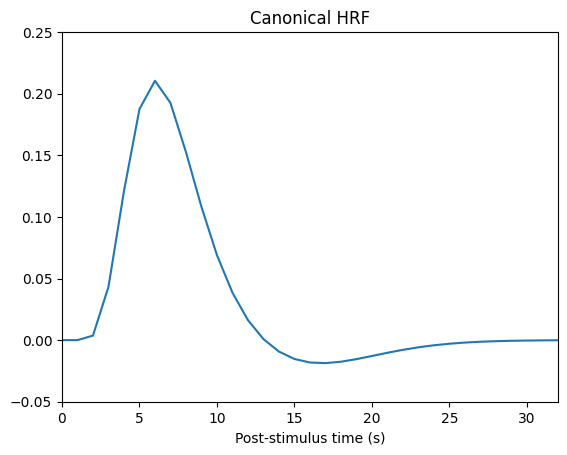

```python
def canonical_hrf(dt):
    # Haemodynamic response function (HRF) = SPM's difference of 2 gamma functions
    p = [6, 16, 1, 1, 6, 0, 32]  # default parameters
    u = np.arange(0, np.ceil(p[6] / dt) + 1) - p[5] / dt
    hrf = sp.stats.gamma.pdf(u, p[0] / p[2], p[2] / dt) - sp.stats.gamma.pdf(u, p[1] / p[3], p[3] / dt) / p[4]
    hrf = hrf / np.sum(hrf)
    return hrf

hrf = canonical_hrf(1)
plt.figure(); plt.plot(np.arange(33), hrf);
plt.axis([0, 32, -0.05, 0.25]); plt.xlabel('Post-stimulus time (s)'); plt.title('Canonical HRF');
```

We can now simulate fMRI data by convolving it with delta functions that represent brief neural activity assumed to occur whenever we present a stimulus:

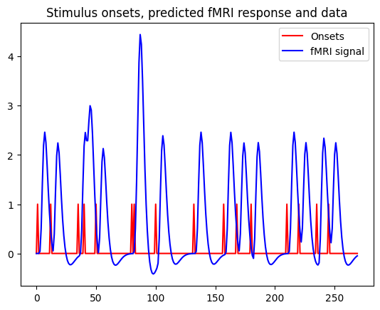

```python
N = 270  # A run of 270 fMRI scans
# Create some onsets, roughly jittered across run:
r = [1, 12, 35, 40, 50, 80, 82, 100, 132, 157, 168, 180, 210, 220, 235, 245]
ons = np.zeros(N)
ons[r] = 1

plt.figure(); plt.plot(ons, color='r'); plt.title('Stimulus onsets, predicted fMRI response and data');
ys = np.convolve(ons, hrf)[:N] # Convolve with HRF
ys = ys / np.std(ys)  # scale so visible on same axis
plt.plot(ys, color='b'); plt.legend(['Onsets', 'fMRI signal']);
```

Some of the autocorrelation comes from the noise though - for example, ongoing neural activity unrelated to our stimuli, which would also be expressed via the HRF, plus aliased biorhythms (such as cardiac), plus slow "scanner drift":

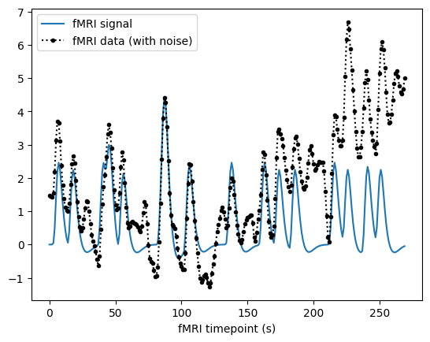

```python
plt.figure(); plt.plot(ys);
np.random.seed(1) # ensure some reasonable (reproducible) noise
n = np.convolve(np.random.randn(N)*2, hrf)[:N] # non-stimulus-locked neural noise, expressed through same HRF
y = ys + n
d = np.arange(1, N+1)[:,np.newaxis] # create some slow drift too
d = np.sum(polynom(d,2),axis=1)
y = y + d
plt.plot(y, ':k.'); plt.axis('tight'), plt.xlabel('fMRI timepoint (s)');
plt.legend(['fMRI signal', 'fMRI data (with noise)']);
```

### Temporal Basis Sets, Filtering and Autocorrelated error

If we do not know the shape of the HRF, we can use a "temporal basis set". Several options are discussed in the literature, but here will use an "FIR" basis set of tophat functions every 2s of the 32s after each onset. This produces the design matrx below, which we can estimate with a GLM:

```
F-test for FIR (assuming error white): F(16,253)=6.396, p=0.000
```

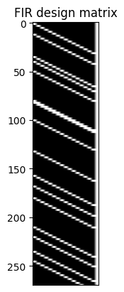

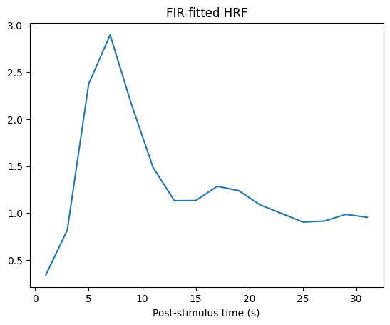

```python
num_bins = int(16) # Number of bins
bin_dur  = int(2)  # Bin duration (s)
FIR = np.kron(np.eye(num_bins),np.ones((bin_dur,1)))
X = np.zeros((N,num_bins))
for b in range(num_bins):
    X[:,b] = np.convolve(ons,FIR[:,b])[:N]
X = np.append(X, np.ones((N,1)), axis=1)
plt.figure(); plt.imshow(X, cmap='gray', aspect=0.25);
plt.title('FIR design matrix'); plt.xticks([]);

B, sigma, R2, r = glm_fit(y, X)
plt.figure(); plt.plot(np.round(np.arange(0.5,num_bins,1)*bin_dur), B[:-1] + B[num_bins])
plt.xlabel('Post-stimulus time (s)'); plt.title('FIR-fitted HRF');
T,F,df,p = glm_con(np.eye(num_bins), X, B, sigma, r)
print(f'F-test for FIR (assuming error white): F({int(df[0])},{int(df[1])})={F:.3f}, p={p:.3f}')
```

The FIR parameters roughly resemble the true HRF used to create the data, and the F-test suggests that there is a (highly) significant stimulus-locked response. Note this is effectively a "deconvolution", and there are other temporal basis sets possible (which could also be applied to overlapping ERPs to stimuli that are jittered over intervals <~1s).

However, this F-test assumes the error is IID, ie spherical, which we can see is unlikely from the residuals: they show temporal smoothness and slow drift, given the way the noise was created above:

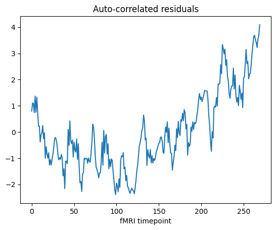

```python
plt.figure(); plt.plot(r); plt.xlabel('fMRI timepoint'); plt.title('Auto-correlated residuals');
```

Some of the typical autocorrelation in fMRI noise (that induced by the slow drift above) can be removed by high-pass filtering, which can be achieved by adding a set of sinusoids to the design matrix (so-called "Discrete Cosine Transform", DCT):

```
F-test for FIR (assuming error white): F(16,249)=26.273, p=0.000
```

[figure not shown]

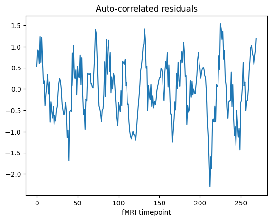

```python
HPC = int(np.fix(2*N/128 + 1)) # DCT cutoff if highpass filtering to 1/128s
DCT = np.full((N, HPC), np.nan)
t = np.arange(N)
for k in range(HPC):
    DCT[:, k] = np.sqrt(2/N) * np.cos(np.pi * (2*t + 1) * k / (2*N))
X = np.concatenate((X, (DCT - DCT.mean(axis=0)) / DCT.std(axis=0)), axis=1)
plt.figure(); plt.imshow(X, cmap='gray', aspect=0.25);
plt.title('FIR design matrix now with High-pass filter'); plt.xticks([]);
B, sigma, R2, r = glm_fit(y, X)

c = np.eye(num_bins)
T,F,df,p = glm_con(c, X, B, sigma, r)
print(f'F-test for FIR (assuming error white): F({int(df[0])},{int(df[1])})={F:.3f}, p={p:.3f}')
plt.figure(); plt.plot(r); plt.xlabel('fMRI timepoint'); plt.title('Auto-correlated residuals');
```

While the residuals no longer show slow drift (and the F-statistic has increased), they are still autocorrelated. One way to model this specific type of nonsphericity is an "AR(p)" model (p-th order autoregressive model). If we assume an "AR(1) + white noise" model, for example, this predicts that the (population) error covariance can be modelled as a combination of two "covariance components" (Q below): the first predicted by the AR(1) component and the second repesenting additional independent (white) noise at each timepoint:

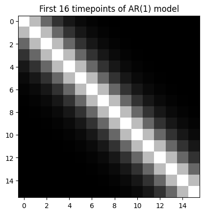

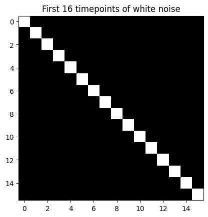

```python
Q = [None] * 2
t = np.arange(1, N+1)
Q[0] = sp.linalg.toeplitz(t * np.exp(-t))
Q[1] = np.eye(N)
plt.figure(); plt.imshow(Q[0][:16,:16], cmap='gray'); plt.title('First 16 timepoints of AR(1) model');
plt.figure(); plt.imshow(Q[1][:16,:16], cmap='gray'); plt.title('First 16 timepoints of white noise');
```

If we assume that the error comes from such an AR(1)+WN error process, then we can use an estimate of this to "pre-whiten" the data. This prewhitening matrix "W" is estimated by the "estimate_autocorrelation" function:

```python
from scipy.linalg import pinv, sqrtm

def estimate_autocorrelation(r):
    # Fit an AR(1)+white noise model to covariance of residuals (V)
    # and return a pre-whitening matrix W. r is samp_size x num_tests
    # of residuals from fitting glm

    N = r.shape[0]
    t = np.arange(1, N+1)
    Q = [sp.linalg.toeplitz(t * np.exp(-t)),  # AR(1)
        np.eye(N)]                    # White Noise
    QX = np.stack((Q[0].flatten(), Q[1].flatten()), axis=1)
    if r.ndim == 1:
        r=r[:,np.newaxis]
    V = r @ r.T
    V = V.flatten()
    h = np.linalg.pinv(QX) @ V
    V = Q[0]*h[0] + Q[1]*h[1]
    W = rsqrtm(pinv(V))
    return V, W

def rsqrtm(V):
    # Matrix square root ensuring real numbers
    u, s, _ = np.linalg.svd(V, full_matrices=False)
    s = np.sqrt(np.abs(s))
    W = np.dot(u, np.dot(np.diag(s), u.T))
    W[np.abs(W) < 1e-6] = 0
    return W
```

We can fit the GLM once to estimate the residuals, estimate the autocorrelation (error) matrix from these, and then multiply both the data and model by the (squareroot) of the inverse of this error covariance:

```python
B,sigma,R2,r = glm_fit(y, X)       # Fit GLM once to estimate residuals
V,W = estimate_autocorrelation(r)  # Estimate autocorrelation from residuals
T,F,df,p,B,R2,r = glm(W@y, W@X, c) # Refit GLM on whitened data and model
print(f'F-test for FIR (pre-whitening with AR(1)+WM), F({df[0]:.0f},{df[1]:.0f})={F.item():.2f}, p={p.item():.3f}')
```

```
F-test for FIR (pre-whitening with AR(1)+WM), F(16,249)=11.85, p=0.000
```

Notice how we have now recovered the original dfs.

However, estimating the true error covariance from the residuals can be inefficient (noisy), as shown below, and mis-estimation can result incorrect statistics after prewhitening. One way to improve its estimation is to pool data across samples, e.g, voxels. If we assume the error covariance is identical across voxels, we can estimate it much more precisely by repeating the above for many voxels, as shown below.

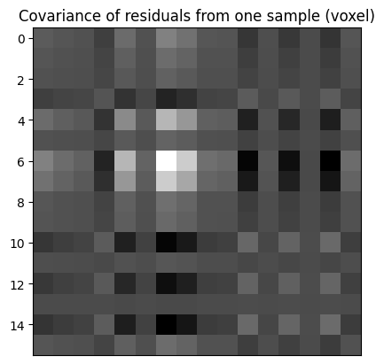

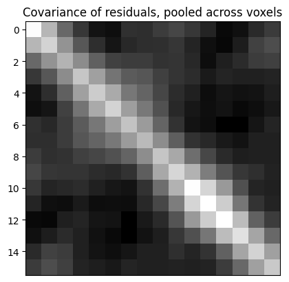

```python
ce = np.outer(r,r); plt.figure(); plt.imshow(ce[:16,:16], cmap='gray', aspect=1);
plt.title('Covariance of residuals from one sample (voxel)'); plt.xticks([]);

num_tests = 100
y = np.random.multivariate_normal(np.zeros(N), Q[0], num_tests).T # y now matrix
with np.errstate(invalid='ignore'): # This is numpy problem after installing pymer4 (see https://github.com/numpy/numpy/issues/24067)
    B, sigma, R2, r = glm_fit(y, X)
    ce = r@r.T; plt.figure(); plt.imshow(ce[:16,:16], cmap='gray', aspect=1);
plt.title('Covariance of residuals, pooled across voxels'); plt.xticks([]);
```

Note that we are calling the "glm_fit" function with a time-by-voxel matrix rather than vector of data, which is useful for simultaneously fitting a large number of GLMs. If you run the code below (though it will take a while), you can see that such "voxel-wide" estimation of nonsphericity results in better control of FPR than trying to estimate on each voxel separately:

```python
N = 90 # Take subset of timepoints to speed up
ys = np.convolve(ons, hrf)[:N]; ys = ys / np.std(ys) # Convolve with HRF
ys = np.repeat(ys[:,np.newaxis], num_tests, axis=1)
X = X[:N,:(num_bins+1)] # No drifts in data

num_samp = int(1e2)  # to speed-up - better as 1e3+
num_tests = int(1e1) # to speed-up - better as int(1e2)
p = np.empty((num_samp,num_tests))
pp = np.empty((num_samp,num_tests))
for s in range(num_samp):
    #y = ys + np.random.multivariate_normal(np.zeros(N), Q[0][:N,:N]*5, num_tests).T # if want some signal
    y = np.random.multivariate_normal(np.zeros(N), Q[0][:N,:N], num_tests).T # If want FPR
    for t in range(num_tests):
        B,sigma,R2,r = glm_fit(y[:,t], X)       # Fit GLM one voxel
        V,W = estimate_autocorrelation(r)
        T,F,df,pval,B,R2,r = glm(W@y[:,t], W@X, c)
        p[s,t] = pval
    with np.errstate(invalid='ignore'):    # This is a numpy problem after installing pymer4 (see https://github.com/numpy/numpy/issues/24067)
        B,sigma,R2,r = glm_fit(y, X)       # Fit GLM to all voxel simultaneously
        V,W = estimate_autocorrelation(r)
        T,F,df,pval,B,R2,r = glm(W@y, W@X, c)
    pp[s,:] = pval

fpr = np.sum(p < alpha, axis=0) / num_samp
print(f'Voxel-wise nonsphericity correction, mean FPR={np.mean(fpr):.3f}')
#print(f'Voxel-wise nonsphericity correction, std FPR={np.std(fpr):.3f}')
fpr = np.sum(pp < alpha, axis=0) / num_samp
print(f'Voxel-wide nonsphericity correction, mean FPR={np.mean(fpr):.3f}')
#print(f'Voxel-wide nonsphericity correction, std FPR={np.std(fpr):.3f}')
```

```
Voxel-wise nonsphericity correction, mean FPR=0.234
Voxel-wide nonsphericity correction, mean FPR=0.079
```

However, even when pooling across voxels in the voxel-wide analysis, we are not controlling the FPR properly. This is because the residuals do not capture just the true error, but also effects of removing the signal (what can be explained by the design matrix). The proper way is to estimate the GLM parameters (B) and the error model (hyper)parameters (h) simultaneously, using an iterative algorithm like "Restricted Maximum Likelihood" (ReML). This is a special case of the Expectation-Maximisation (EM) algorithm, and sometimes called an Empirical Bayesian approach. This is available in many software packages (including that used for the mixed effects models below), but is beyond the present remit. (It is also the basis of the popular COMBAT algorithm used to harmonise neuroimaging data across scanners.)

Finally, note that even without a task, the GLM can be used to estimate functional connectivity between two voxels/ROIs, by putting the timeseries of one ROI into X, together with confounds like above, when fitting the timeseries from the other ROI. The resulting p-value will be properly adjusted for filtering, autocorrelation etc, unlike when simply estimating the Pearson correlation coefficient between two ROIs after preprocessing their data independently.

## Heirarchical Linear Models

So far, we have modelled just one source of error variance (one "random effect"), e.g, across participants in the T-tests and ANOVAs, or across timepoints in the timeseries analyses. We often have mulitple measurements (within each condition) for each of mulitple participants. For example, we might collect reaction times from 100 trials in each of 10 participants. In this case, our power depends on both the variance across trials within participants, and the variance in the mean across participants. This can be modelled properly in "mixed effects" models below, but first we start with a common approximation, which is to average across trials within each participant, and simply perform a test on these means across participants (i..e, ignoring the error associated with each trial-average).

This is sometimes called the "summary statistic" or two-stage approach. It is illustrated below, along with effects of the number of trials relative to number of participants:

```python
np.random.seed(1)
num_ppt = [10, 20, 10]   # Number of participants
num_trl = [100, 10, 20]  # Number of trials per participant
pop_std = [1, 1, 1]      # Std of mean across participants
trl_std = [10, 10, 10]   # Std across trials
pop_mean = 1
num_samp = 1000
for e in range(len(num_ppt)):
    pop_ppt = pop_mean + pop_std[e] * pop
    ppt_mean = sample_pop(pop_ppt, num_ppt[e], num_samp)
    y = np.full((num_ppt[e], num_samp), np.nan)
    for p in range(num_ppt[e]):
        for s in range(num_samp):
            pop_trl = ppt_mean[p, s] + trl_std[e] * pop
            ppt_vals = sample_pop(pop_trl, num_trl[e], 1)
            y[p, s] = np.mean(ppt_vals)
    pval = T2p_higher(one_t(y), num_ppt[e] - 1)
    pr = np.sum(pval < alpha) / num_samp
    print(f'Positive rate with {num_ppt[e]} participants with {num_trl[e]} trials = {pr:.2f}')
```

```
Positive rate with 10 participants with 100 trials = 0.65
Positive rate with 20 participants with 10 trials = 0.35
Positive rate with 10 participants with 20 trials = 0.33
```

In this situation where variability across trials is much higher than variability across participants, having 10x more trials produces higher power than having 2x more participants (cf. the first two results above); though if the total number of trials (ie, num_ppt*num_trls) is fixed, it is generally better to have more participants (cf. the last two results above).

**Exercise: Try situation where variability across trials is less than than variability across participants?**

But what happens if different participants have different numbers of trials? Let's build up some data first:

```python
num_ppt = 20
pop_std = 1
trl_std = 10
alpha = 0.05
num_trl = [10*p for p in range(1, num_ppt+1)] # participants ordered by number of trials!
pop_ppt  = pop*pop_std + pop_mean
ppt_mean = sample_pop(pop_ppt, num_ppt, num_samp)

samp_means = np.full((num_ppt, num_samp), np.nan)
samp_vals = np.full((sum(num_trl), num_samp), np.nan)

for s in range(num_samp):
    vals = np.array([])
    for p in range(num_ppt):
        pop_trl  = ppt_mean[p,s] + trl_std*pop
        ppt_vals = sample_pop(pop_trl, num_trl[p], 1)
        samp_means[p, s] = np.mean(ppt_vals)
        vals = np.vstack((vals, ppt_vals)) if vals.size else ppt_vals
    samp_vals[:, s] = np.squeeze(vals) # Used in LME below
```

In this case, the mean for a participant who did more trials is a more accurate estimate, so we could increase the contribution of this participant's mean to the estimate of the population mean. This is called "weighting" (a simple case of "weighted least squares"), which can produce more sensitive tests, as illustrated below:

```python
# Unweighted test on means
pval = T2p_higher(one_t(samp_means),num_ppt-1)
pr = np.sum(pval < alpha) / num_samp
print(f'Power for standard T-test = {pr:.2f}')

# Weighted least squares
w = np.repeat(np.array([num_trl]), num_samp, axis=0).T
wm = np.sum(np.multiply(samp_means,w),axis=0) / np.sum(w,axis=0)
wv = (np.sum(np.multiply(samp_means**2,w),axis=0) / np.mean(w,axis=0) - num_ppt * wm**2) / (num_ppt - 1)
wT = wm / (np.sqrt(wv) / np.sqrt(num_ppt))
pval = T2p_higher(wT, num_ppt-1)
pr = np.sum(pval < alpha) / num_samp
print(f'Power for weighted T-test = {pr:.2f}')
```

```
Power for standard T-test = 0.81
Power for weighted T-test = 0.90
```

Note how giving more weight to participants whose mean has been estimated from more trials results in a more powerful final test. Such highly "unbalanced" designs are where the summary statistic approach (that ignores estimation errror associated with each participant) becomes non-optimal. However, this weighting is just a simple case of more general "mixed effects" models, to which we next turn, in which one can have more than one random effect, i.e., variance due to participants, variance due to trials, etc...

More generally, this situation can be represented as a heirarchical set of GLMs:

```
y    = X1 * B1 + e1

B1  = X2 * B2 + e2
```

So in example above, B1 captures the mean across trials for each participant, while B2 is the mean across participants. In a Bayesian context, B2 can also function as an "empirical prior" that can "regularise" the estimates of individual participant means (B1). Note that there can be more than 2 levels (e.g, trials, sessions, participants), and also that the second level does not have to refer to participants; the second-level could refer to the mean across voxels for example ("spatial regularisation").

### Linear Mixed Effects (LME) Models

We finish with LME models, which can no longer be solved by simply matrix inversion (OLS/WLS), and require iterative techniques like ReML mentioned above. Because these are quite complex in general, we switch to calling the "lmer" function from the "R" freeware package (via the python "pymer4" API). First though, we need to represent the data more generally, in which each observation is a row, and each column indicates where that observation comes from, e.g, a particular participant ID, condition and possiby a particular stimulus ID (sometimes called "long-format"). In the python package "polars", these are called "data frames".

Let's start by creating a long-format table for the data created above, with just one condition and variable numbers of trials across participants:

```python
import polars as pl

part_ID = []
for p in range(num_ppt):
    for t in range(num_trl[p]):
        part_ID.append(str(p + 1))   # string is a safe choice for grouping IDs

tab = pl.DataFrame({
    "y": samp_vals[:, 0],
    "Participant": part_ID,
})
```

We can now fit an LME model. The generic "Wilkinson" notation for such a model is "y ~ 1 + F1 + (1 + F1|R1)", where the "1" represents an intercept, F1 is a fixed effect and R1 is a random effect (e.g., participants). We will demonstrate more than one fixed and random effect later. The term "(1|R1)" is known as the "random intercept" (e.g, capturing the mean of each participant; akin to the participant columns in the GLM section earlier), and the term "(F1|R1)" is a "random slope" (e.g, allowing for the possibility that different participants show different effect sizes of F1).

*Interesting factoid: I couldn't find any interesting factoid about Graham Wilkinson, except that he liked to design new ways of representing railway timetables.*

However, for the one-sample T-test example above, there is just an intercept (no other fixed effect) and there is only a random intercept, so the model is simply "y ~ 1 + (1|participant)":

```python
from pymer4.models import lmer

model = lmer("y ~ 1 + (1|Participant)", data=tab)
model.fit(summary=True)
```

Formula: lmer(y~1+(1|Participant))

Number of observations: *2100* Confidence intervals: *parametric* --------------------- Log-likelihood: *-7819* AIC: *15644* | BIC: *15661* Residual error: *9.986*

| Random Effects: |  | Estimate | SE | CI-low | CI-high | T-stat | DF | p |  |
| --- | --- | --- | --- | --- | --- | --- | --- | --- | --- |
| Participant-sd | (Intercept) | 1.047 |  |  |  |  |  |  |  |
| Residual-sd | Observation | 9.986 |  |  |  |  |  |  |  |
| Fixed Effects: |  |  |  |  |  |  |  |  |  |
|  | (Intercept) | 1.345 | 0.335 | 0.646 | 2.043 | 4.012 | 20.187 | <.001 | *** |

Signif. codes: *0 *** 0.001 ** 0.01 * 0.05 . 0.1*

We can then compare the power of LME with WLS and summary statistic approaches above (though it will take several minutes to run):

```python
from IPython.utils.io import capture_output # to suppress output from each LME fit below

num_samp = int(1e3) # Should be 1e3 to compare to above

with capture_output():
    pval = np.full((num_samp, 1), np.nan)
    for s in range(num_samp):
        tab = pl.DataFrame({
            "y": samp_vals[:, s],
            "Participant": part_ID,
        })

        model = lmer("y ~ 1 + (1|Participant)", data=tab)
        model.fit()

        #pval[s] = model.coefs["P-val"].item() # This actually uses Satterthwaite correction to dfs which don't want right now
        tval = model.result_fit["t_stat"].item()
        pval[s] = T2p_2tails(tval, len(tab) - num_ppt - 1)

pr = np.sum(pval < alpha) / num_samp
print(f"Power for LME = {pr:.2f}")
```

```
Power for LME = 0.85
```

which is higher than for the unweighted two-stage T-tests in the preceding section (and closer to that for weighted T-tests). This is largely because of the massive increase in dfs (at price of needing a more complex model of random effects).

### Simpsons paradox

This paradox relates to a pattern of data in which an independent variable shows a relationship with the dependent variable across trials within each participant, but a relationship of the opposite sign for the means across trials. This is plotted below, where each participant's data is a different colour, while the black line shows the linear fit to the means across participants (using the GLM to estimate those linear slopes).

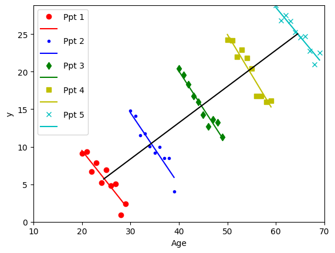

```python
num_trl = 10
num_ppt = 5
ppt_ID = []
age = np.empty([num_trl, num_ppt])
y = np.empty([num_trl, num_ppt])
ppt_age = np.arange(20, 10*(num_ppt+1)+1, 10)

fig, ax = plt.subplots()
mker = ['ro', 'b.', 'gd', 'ys', 'cx']
txt = []
for p in range(num_ppt):
    for t in range(num_trl):
        age[t,p] = ppt_age[p] + t
        y[t,p]  = ppt_age[p]*0.5 - t + np.random.randn()
    ppt_ID.extend([p+1] * num_trl)
    ax.plot(age[:,p], y[:,p], mker[p])
    X = np.stack((age[:,p], np.ones(num_trl)), axis=1)
    _,_,_,_,B,_,_ = glm(y[:,p], X, np.array([1, 0]))
    X = np.array([age[0,p], age[num_trl-1,p]])
    ax.plot(X, B[0]*X + B[1], color=mker[p][0])
    txt.append(f'Ppt {p+1}'); txt.append('')

X = np.stack((np.mean(age,axis=0).T, np.ones(num_ppt)), axis=1)
_,_,_,_,B,_,_ = glm(np.mean(y,axis=0).T, X, np.array([1, 0]))
X = np.array([np.mean(age[:,0]), np.mean(age[:,num_ppt-1])])
ax.plot(X, B[0]*X + B[1], color='k');
ax.set_xlim(10, 10*(num_ppt+2)); ax.set_ylim(0, np.max(y));
ax.set_xlabel('Age'); ax.set_ylabel('y');
ax.legend(txt, loc='upper left');

tab = pl.DataFrame({
    "y": y.T.flatten(),
    "Age": age.T.flatten(),
    "Participant": ppt_ID,
})
```

Notice how there is a positive effect of age on the mean values across participants, but a negative effect of age within each participant. If we fit an LME:

```python
model = lmer("y ~ Age + (1|Participant)", data=tab)
model.fit(summary=True)
```

Formula: lmer(y~Age+(1|Participant))

Number of observations: *50* Confidence intervals: *parametric* --------------------- Log-likelihood: *-91* AIC: *190* | BIC: *198* Residual error: *1.026*

| Random Effects: |  | Estimate | SE | CI-low | CI-high | T-stat | DF | p |  |
| --- | --- | --- | --- | --- | --- | --- | --- | --- | --- |
| Participant-sd | (Intercept) | 22.129 |  |  |  |  |  |  |  |
| Residual-sd | Observation | 1.026 |  |  |  |  |  |  |  |
| Fixed Effects: |  |  |  |  |  |  |  |  |  |
|  | (Intercept) | 56.097 | 10.148 | 28.843 | 83.351 | 5.528 | 4.373 | 0.004014 | ** |
|  | Age | −0.915 | 0.050 | −1.017 | −0.814 | −18.159 | 44.419 | <.001 | *** |

Signif. codes: *0 *** 0.001 ** 0.01 * 0.05 . 0.1*

we see a negative effect of Age, as expected (with the different means across participants accommodated by the random intercepts). One explanation for this pattern could be a variable like "environmental pollution", which might increase over the years and impair cognitive development during childhood, but because older people were born earlier (when there was less pollution), there is a positive effect of age on their average scores.

### Model Comparison

The real advantage of LME models comes with more complex heirarchical designs with multiple random effects. So let's generate some data from two fixed effects (a 2x2 design), in which there is a main effect of the second factor (f2), and in which each randomly-sampled participant is tested on a set of randomly-sampled stimuli (i.e., two random effects):

```python
np.random.seed(1)
pop_mean = 1
pop_std = 2
num_ppts = 20  # Number of participants
ppt_vals = np.random.randn(num_ppts) * pop_std + pop_mean

stm_mean = 1
stm_std = 4
num_stms = 10  # Number of stimuli
stm_vals = np.random.randn(num_stms) * stm_std + stm_mean
# stm_vals[5:10] += 4  # Uncomment if want f2 to be confounded by stimuli

cond_vals = np.array([[-1, 1], [-1, 1]])  # fixed effects in 2x2 design (main effect of f2)

trl_std = 1  # Noise on each trial

ppt_ids = []; f1_ids = []; f2_ids = []; stm_ids = []; y = []
for f1 in range(2):
    for f2 in range(2):
        for p in range(num_ppts):
            for s in range(num_stms):
                yt = np.random.randn() * trl_std + cond_vals[f1, f2] + ppt_vals[p] + cond_vals[f1, f2] * ppt_vals[p] + stm_vals[s]
                # yt = np.random.randn() * trl_std + cond_vals[f1, f2] + ppt_vals[p] + cond_vals[f1, f2] * ppt_vals[p] + stm_vals[(f2) * num_stms // 2 + s // 2]  # Uncomment if stimulus ID differs by f2
                y.append(yt)
                f1_ids.append(f1 + 1)  # factor 1 level
                f2_ids.append(f2 + 1)  # factor 2 level
                ppt_ids.append(p + 1)  # participant ID
                stm_ids.append(s + 1)  # stimulus ID
                # stm_ids.append((f2) * num_stms // 2 + (s // 2) + 1)  # Uncomment if stimulus ID differs by f2

# Create a DataFrame similar to MATLAB's table
tab = pl.DataFrame({
    'y': y,
    'F1': f1_ids,
    'F2': f2_ids,
    'Participant': ppt_ids,
    'Stimulus': stm_ids
})

# Display the first 6 rows
print(tab.head(6))
```

```
shape: (6, 5)
┌───────────┬─────┬─────┬─────────────┬──────────┐
│ y         ┆ F1  ┆ F2  ┆ Participant ┆ Stimulus │
│ ---       ┆ --- ┆ --- ┆ ---         ┆ ---      │
│ f64       ┆ i64 ┆ i64 ┆ i64         ┆ i64      │
╞═══════════╪═════╪═════╪═════════════╪══════════╡
│ -5.094137 ┆ 1   ┆ 1   ┆ 1           ┆ 1        │
│ 4.182141  ┆ 1   ┆ 1   ┆ 1           ┆ 2        │
│ 2.91919   ┆ 1   ┆ 1   ┆ 1           ┆ 3        │
│ 1.164772  ┆ 1   ┆ 1   ┆ 1           ┆ 4        │
│ 2.932178  ┆ 1   ┆ 1   ┆ 1           ┆ 5        │
│ -2.747576 ┆ 1   ┆ 1   ┆ 1           ┆ 6        │
└───────────┴─────┴─────┴─────────────┴──────────┘
```

Note that we have also added a random slope for f2 with the term *"cond_vals(f1,f2)*ppt_vals(p)"* above. We can now fit a series of models, and use model comparison to determine the best one. We start with assuming only random intercepts below. Note that the "*" is a symbol used to indicate a factorial design, such that "f1*f2" expands to "f1 + f2 + f1:f2", where "f1:f2" is the interaction term (i.e, the two factors expand to three fixed effects):

```python
m1 = lmer("y ~ F1*F2 + (1|Participant) + (1|Stimulus)", data=tab)
display(m1.fit(summary=True))

l1 = m1.result_fit_stats["logLik"].item()
aic1 = m1.result_fit_stats["AIC"].item()

print(f'\nRandom intercepts only: LogLikelihood = {l1:.0f}, AIC = {aic1:.0f}')
```

Formula: lmer(y~F1*F2+(1|Participant)+(1|Stimulus))

Number of observations: *800* Confidence intervals: *parametric* --------------------- Log-likelihood: *-1910* AIC: *3835* | BIC: *3868* Residual error: *2.455*

| Random Effects: |  | Estimate | SE | CI-low | CI-high | T-stat | DF | p |  |
| --- | --- | --- | --- | --- | --- | --- | --- | --- | --- |
| Participant-sd | (Intercept) | 2.216 |  |  |  |  |  |  |  |
| Stimulus-sd | (Intercept) | 3.289 |  |  |  |  |  |  |  |
| Residual-sd | Observation | 2.455 |  |  |  |  |  |  |  |
| Fixed Effects: |  |  |  |  |  |  |  |  |  |
|  | (Intercept) | −2.819 | 1.442 | −5.758 | 0.120 | −1.954 | 31.851 | 0.05949 | . |
|  | F1 | −0.045 | 0.549 | −1.123 | 1.032 | −0.083 | 768.000 | 0.934 |  |
|  | F2 | 3.320 | 0.549 | 2.243 | 4.398 | 6.049 | 768.000 | <.001 | *** |
|  | F1:F2 | 0.011 | 0.347 | −0.671 | 0.692 | 0.031 | 768.000 | 0.9756 |  |

Signif. codes: *0 *** 0.001 ** 0.01 * 0.05 . 0.1*

```
Random intercepts only: LogLikelihood = -1911, AIC = 3835
```

This recovers the significant main effect of F2, but is potentially invalid because we are not allowing for the possiblity that each fixed effect could depend on participant, i.e, we are not modelling random slopes (i.e, ignoring structure in the error). So alternatively, we could fit the most complex model and compare to the model above, using a Likelihood Ratio Test (for nested models) or AIC (for any models):

```python
m2 = lmer("y ~ F1*F2 + (F1*F2|Participant) + (F1*F2|Stimulus)", data=tab)
display(m2.fit(summary=True))

l2 = m2.result_fit_stats["logLik"].item()
aic2 = m2.result_fit_stats["AIC"].item()
print(f'\nMost complex model: LogLikelihood = {l2:.0f}, AIC = {aic2:.0f}')

# Code for likelihood ratio test
from scipy.stats import chi2
C2 = -2*(l1-l2)
df_m1 = (aic1+2*l1)/2 # Hacky way of getting dfs!
df_m2 = (aic2+2*l2)/2 # Hacky way of getting dfs!
df_diff = df_m2 - df_m1
#df_diff = (20+10)*3 # 20 participant slopes and 10 stimulus slopes for 3 new effects
p = 1 - chi2(df_diff).cdf(C2)
print(f'\nDifference in LogLikelihoods = {(l1-l2):.0f}, df = {df_diff:.0f}, p = {p:.3f}')
```

[output not shown]

Formula: lmer(y~F1*F2+(F1*F2|Participant)+(F1*F2|Stimulus))

Number of observations: *800* Confidence intervals: *parametric* --------------------- Log-likelihood: *-1222* AIC: *2494* | BIC: *2611* Residual error: *0.983*

| Random Effects: |  | Estimate | SE | CI-low | CI-high | T-stat | DF | p |  |
| --- | --- | --- | --- | --- | --- | --- | --- | --- | --- |
| Participant-sd | (Intercept) | 4.948 |  |  |  |  |  |  |  |
| Participant-sd | F1 | 0.475 |  |  |  |  |  |  |  |
| Participant-sd | F2 | 4.765 |  |  |  |  |  |  |  |
| Participant-sd | F1:F2 | 0.286 |  |  |  |  |  |  |  |
| Stimulus-sd | (Intercept) | 3.738 |  |  |  |  |  |  |  |
| Stimulus-sd | F1 | 0.451 |  |  |  |  |  |  |  |
| Stimulus-sd | F2 | 0.495 |  |  |  |  |  |  |  |
| Stimulus-sd | F1:F2 | 0.244 |  |  |  |  |  |  |  |
| Participant-cor | (Intercept) | −0.631 |  |  |  |  |  |  |  |
| Participant-cor | (Intercept) | −1.000 |  |  |  |  |  |  |  |
| Participant-cor | (Intercept) | 0.628 |  |  |  |  |  |  |  |
| Participant-cor | F1 | 0.621 |  |  |  |  |  |  |  |
| Participant-cor | F1 | −1.000 |  |  |  |  |  |  |  |
| Participant-cor | F2 | −0.618 |  |  |  |  |  |  |  |
| Stimulus-cor | (Intercept) | −0.831 |  |  |  |  |  |  |  |
| Stimulus-cor | (Intercept) | −0.487 |  |  |  |  |  |  |  |
| Stimulus-cor | (Intercept) | 0.764 |  |  |  |  |  |  |  |
| Stimulus-cor | F1 | 0.890 |  |  |  |  |  |  |  |
| Stimulus-cor | F1 | −0.994 |  |  |  |  |  |  |  |
| Stimulus-cor | F2 | −0.936 |  |  |  |  |  |  |  |
| Residual-sd | Observation | 0.983 |  |  |  |  |  |  |  |
| Fixed Effects: |  |  |  |  |  |  |  |  |  |
|  | (Intercept) | −2.819 | 1.656 | −6.258 | 0.620 | −1.702 | 21.469 | 0.1031 |  |
|  | F1 | −0.045 | 0.283 | −0.642 | 0.551 | −0.161 | 17.058 | 0.8741 |  |
|  | F2 | 3.320 | 1.099 | 1.025 | 5.616 | 3.021 | 19.676 | 0.00684 | ** |
|  | F1:F2 | 0.011 | 0.171 | −0.348 | 0.369 | 0.062 | 18.986 | 0.9512 |  |

Signif. codes: *0 *** 0.001 ** 0.01 * 0.05 . 0.1*

```
Most complex model: LogLikelihood = -1222, AIC = 2494

Difference in LogLikelihoods = -689, df = 18, p = 0.000
```

Model comparison shows that m2 is a better model (according to LRT, and AIC, where lower AIC is better). The p-value for the main effect of F2 has also increased slightly (less significant) because we are now correctly modelling structure in the error. However, notice that there are some warnings during estimation of this complex model, which often suggests that we should fit a simpler one. Indeed, we know this model is overly complex (since we generated data with only one random slope), so we can also fit the "true" model:

```python
m3 = lmer("y ~ F2 + (F2|Participant) + (1|Stimulus)", data=tab)
display(m3.fit(summary=True))

l3 = m3.result_fit_stats["logLik"].item()
aic3 = m3.result_fit_stats["AIC"].item()
print(f'\nTrue model: LogLikelihood = {l3:.0f}, AIC = {aic3:.0f}')

C2 = -2*(l3-l2)
df_m3 = (aic3+2*l3)/2 # Hacky way of getting dfs!
df_diff = df_m2 - df_m3
#df_diff = (20+10)*3 # 20 participant slopes and 10 stimulus slopes for 3 new effects
p = 1 - chi2(df_diff).cdf(C2)
print(f'\nDifference in LogLikelihoods = {(l3-l2):.0f}, df = {df_diff:.0f}, p = {p:.3f}')
```

Formula: lmer(y~F2+(F2|Participant)+(1|Stimulus))

Number of observations: *800* Confidence intervals: *parametric* --------------------- Log-likelihood: *-1224* AIC: *2462* | BIC: *2495* Residual error: *0.994*

| Random Effects: |  | Estimate | SE | CI-low | CI-high | T-stat | DF | p |  |
| --- | --- | --- | --- | --- | --- | --- | --- | --- | --- |
| Participant-sd | (Intercept) | 4.528 |  |  |  |  |  |  |  |
| Participant-sd | F2 | 4.511 |  |  |  |  |  |  |  |
| Stimulus-sd | (Intercept) | 3.299 |  |  |  |  |  |  |  |
| Participant-cor | (Intercept) | −1.000 |  |  |  |  |  |  |  |
| Residual-sd | Observation | 0.994 |  |  |  |  |  |  |  |
| Fixed Effects: |  |  |  |  |  |  |  |  |  |
|  | (Intercept) | −2.887 | 1.458 | −5.896 | 0.122 | −1.980 | 23.969 | 0.05924 | . |
|  | F2 | 3.336 | 1.011 | 1.220 | 5.453 | 3.299 | 19.002 | 0.003772 | ** |

Signif. codes: *0 *** 0.001 ** 0.01 * 0.05 . 0.1*

```
True model: LogLikelihood = -1224, AIC = 2462

Difference in LogLikelihoods = -2, df = 18, p = 1.000
```

If you don't know anything about the structure of the error, one approach is to start with the most complex model, and gradually reduce its complexity with a series of model comparisons until the simpler model is no longer sufficient. Note that sometimes (complex) models will not converge, in which case it is often necessary to assume simpler models.

Note that the computational expense of LMEs (and occasional convergence problems) can be an issue when applying over many samples, eg 1e6 voxels in MRI images, but there are simplified approximations, like the "sandwich estimator".

This concludes this brief introduction to statistics for hypothesis testing. Any corrections/comments/additions welcomed!